# Results

## Box and whiskers of weighted-average difference

First, from the full dataset for 2007, 12, and 17 Census years, we start by looking at the amount of missing data for each variable. We drop any columns missing more than 10% of their data.

```
## cons_wet_acres  cons_wetlands          irrig          occup    insur_acres
##       19.19777       19.65894       10.11369       34.28786       10.95024
##        cty_clp        ph_corn       perc_clp       perc_wle
##       10.88589       21.52510       10.98241       11.71171
```

For the counties that are a bright spots based on the weighted average of all crops, let’s look at their attributes (Kate, I’ll clean up labels eventually, haha):

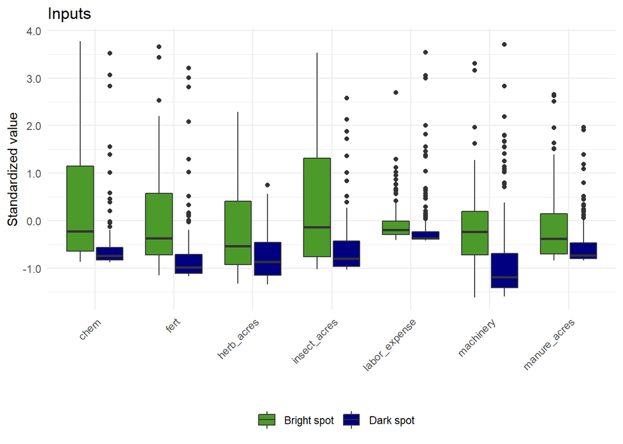

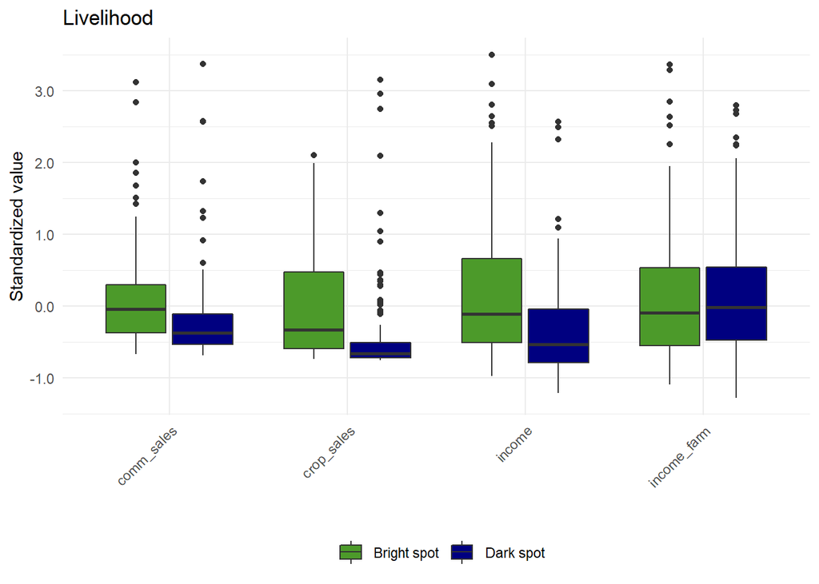

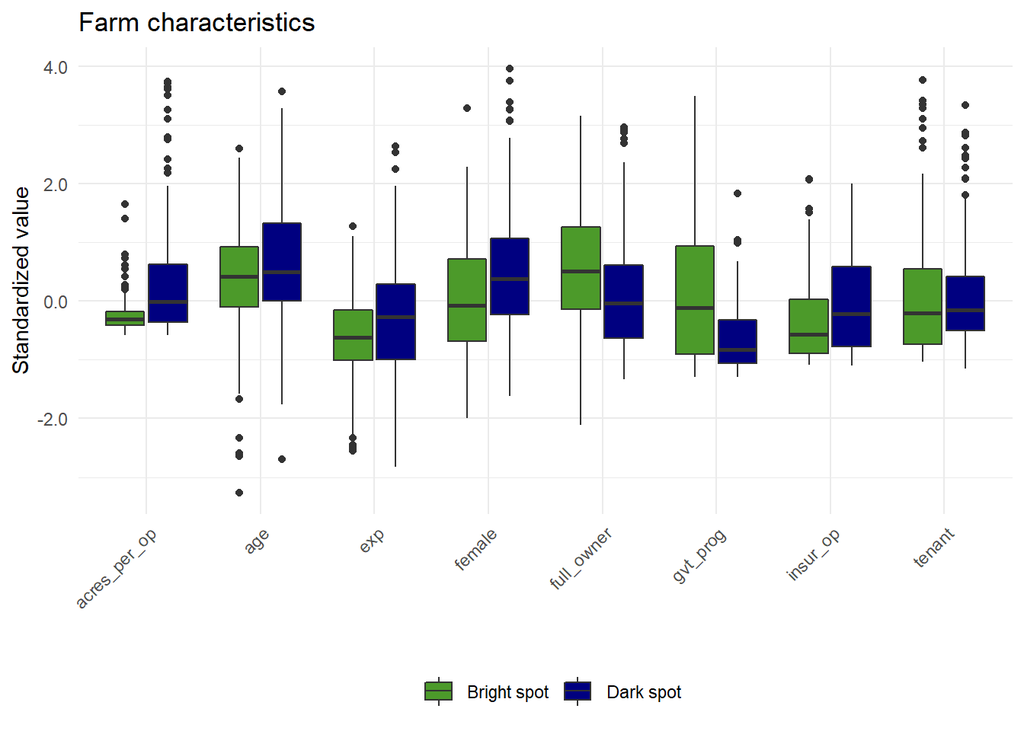

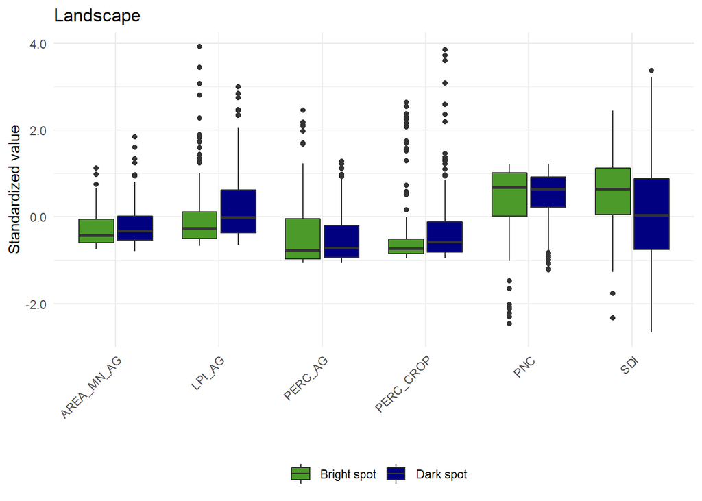